# Variance, Covariance and Correlation: Concepts through Simulation

# 1 The big picture

| Quantity | Question it answers | Formula |
| --- | --- | --- |
| **Variance** | How much does *one* variable bounce around its mean? | $\mathrm{Var}(X)=E[(X-\mu_X)^2]=E[X^2]-\mu_X^2$ |
| **Covariance** | When $X$ is above its mean, is $Y$ usually above (+) or below (−) its mean? | $\mathrm{Cov}(X,Y)=E[(X-\mu_X)(Y-\mu_Y)]=E[XY]-\mu_X\mu_Y$ |
| **Correlation** | The same, but with units removed, between $-1$ and $1$ | $\rho=\dfrac{\mathrm{Cov}(X,Y)}{\sigma_X\sigma_Y}$ |

Three ideas to keep coming back to:

1. Covariance and correlation measure **linear** togetherness only.
2. Independent $\Rightarrow$ covariance $=0$, but **not** the other way around.
3. Correlation is **not** causation.

In each section below we run an experiment, look at the numbers, and interpret them. Each section describes how the data were generated, so the R code itself is hidden. All simulations use a fixed random seed, so the numbers reproduce exactly, but a different seed will change them slightly (that is sampling noise).

# 2 Variance: one variable bouncing around

*Experiment:* the number of minutes your bus is late. Two routes have the **same average** delay (5 minutes) but different reliability. We simulate 10,000 days for each route: Route A delays are Normal with mean 5 and standard deviation 1 (reliable), and Route B delays are Normal with mean 5 and standard deviation 4 (unpredictable).

| route | mean | variance | sd |
| --- | --- | --- | --- |
| A | 5.014810 | 0.982429 | 0.9911756 |
| B | 5.001943 | 15.770157 | 3.9711656 |

The histograms use the same bin width (0.5 minute) for both routes so their heights can be compared directly.

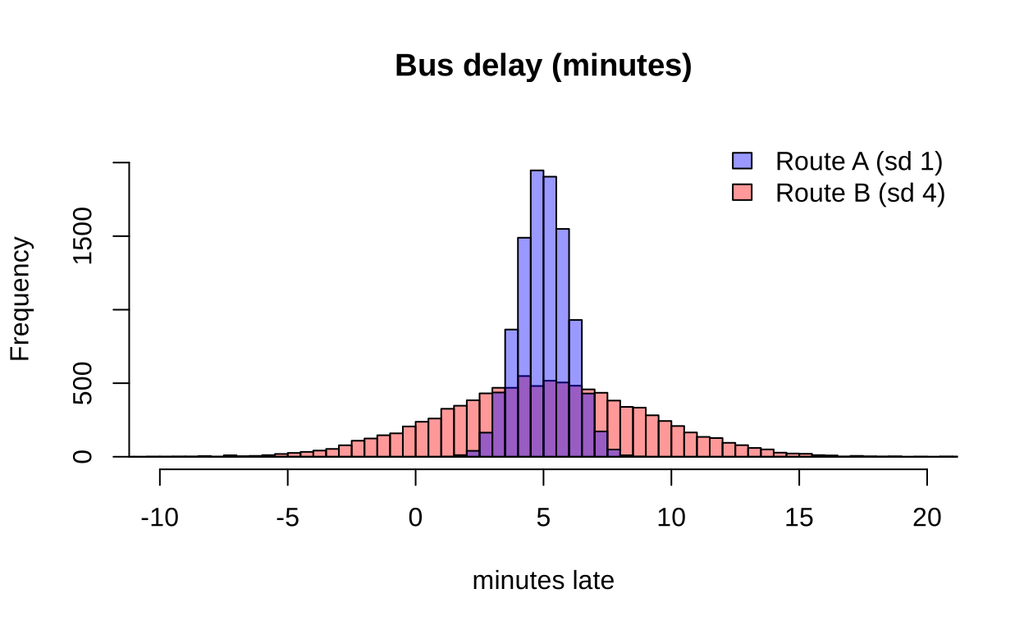

**Interpretation.** Same mean, very different variance. The variance is in *minutes squared*; the standard deviation (the square root) is back in minutes, so we usually quote that.

# 3 Covariance: do two variables move together?

*Experiment:* 200 students. $X$ = hours studied for an exam, $Y$ = exam score. (Simulated: hours studied are Normal with mean 6 and standard deviation 2; score = 55 + 4 × (hours − 6) + random noise with standard deviation 8, so each extra hour adds about 4 points on average.) The first six students:

|  | hours | score |
| --- | --- | --- |
| 1 | 7.5 | 46.4 |
| 2 | 7.3 | 58.4 |
| 3 | 4.5 | 47.1 |
| 4 | 6.4 | 61.7 |
| 5 | 7.3 | 52.0 |
| 6 | 5.0 | 49.3 |

## 3.1 The quadrant picture

Draw a vertical line at the average hours and a horizontal line at the average score (the dashed lines). The product $(x-\bar x)(y-\bar y)$ is **positive** (blue) in the upper-right and lower-left quadrants and **negative** (red) in the other two.

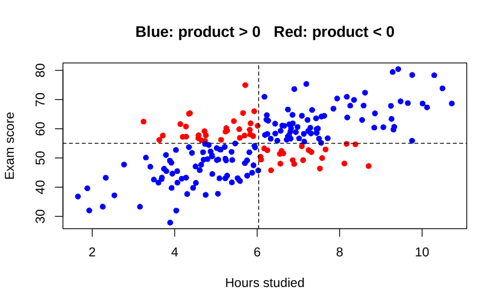

Most points are blue, so the *average* product is positive. That average **is** the covariance. (The sample covariance divides the sum of the products by $n-1$ rather than $n$.) The first number below adds up the products by hand; the second is the result from R’s built-in covariance function:

```
##  by_hand built_in
## 12.15598 12.15598
```

**Interpretation.** A positive covariance means “above-average study time goes with above-average scores”. But what does a covariance of about 12 *mean*? “Hour-points” is not a natural unit, so we need correlation.

## 3.2 Seeing different covariances

Here $X$ and $Y$ are standardized (each has mean 0 and variance 1), so the covariance is simply a measure of how tightly and in which direction the points line up. Each panel shows 1,000 simulated pairs, with the relationship ranging from strongly negative to strongly positive. The dashed red lines mark the means (0, 0). Compare the shapes with the covariance printed on each panel.

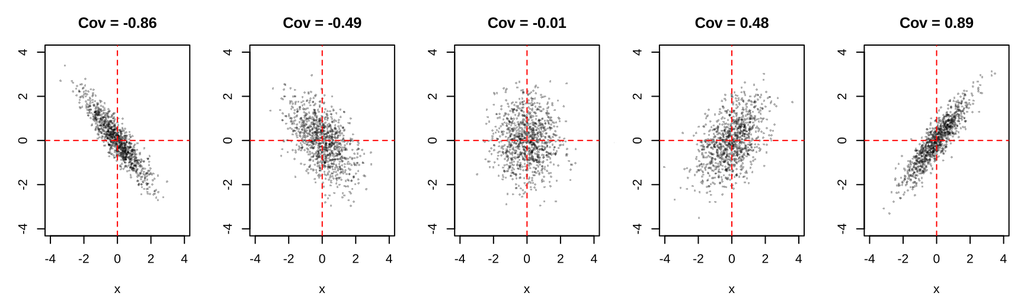

**Interpretation.** Sign = direction (up-right vs. down-right), and a larger absolute value means the points hug a line more tightly.

## 3.3 Same shape, different units, different covariance

Now keep the **same students and the same relationship** (the study-hours data above) but change the units. The three scatterplots below have exactly the same shape; only the numbers on the axes differ.

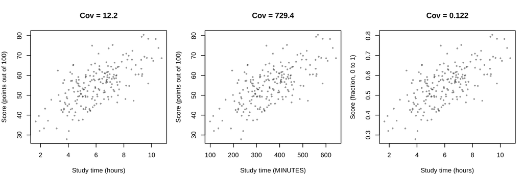

**Interpretation.** Nothing about the relationship changed, yet the covariance went from about 12 to about 730 (hours $\to$ minutes multiplies it by 60) and to about 0.12 (points $\to$ fractions divides it by 100). In general $\mathrm{Cov}(aX,bY)=ab\,\mathrm{Cov}(X,Y)$. So a covariance’s *size* depends on the units, and we can’t say “12 is strong” or “730 is stronger”. The sign is meaningful; the magnitude is not. That is exactly the problem correlation fixes in the next section.

# 4 Correlation: covariance without units

The previous section showed that rescaling the variables changes the covariance even though the picture is the same. Correlation divides out the units, $\rho=\mathrm{Cov}(X,Y)/(\sigma_X\sigma_Y)$, so it only reflects the shape.

*Experiment:* 300 simulated adults. Height is Normal with mean 68 inches and standard deviation 3; weight = 150 + 4 × (height − 68) pounds plus random noise with standard deviation 15. We compute the covariance and correlation twice, once in inches and pounds and once after converting to centimetres (× 2.54) and kilograms (× 0.4536).

| units | covariance | correlation |
| --- | --- | --- |
| inches & pounds | 38.48003 | 0.6299339 |
| centimetres & kilograms | 44.33454 | 0.6299339 |

**Interpretation.** Changing units multiplies the covariance by $2.54\times0.4536\approx1.15$, but the correlation does not move. That is why we compare correlations, not covariances, across different variables. A correlation near $\pm1$ means a tight straight-line pattern; near 0 means no *linear* pattern.

# 5 Experiment: two dice

Roll two fair dice. $D_1$, $D_2$ are the dice, $S=D_1+D_2$, and $G=|D_1-D_2|$ is the gap. There are only 36 equally likely outcomes, so we can compute everything **exactly** by listing all 36 outcomes and averaging over them: with equally likely outcomes, $E[XY]$ is just the average of the product over the 36 rows, and $\mathrm{Cov}(X,Y)=E[XY]-E[X]E[Y]$. We also include $M=\max(D_1,D_2)$. No simulation, so no sampling noise.

```
##                Cov   Corr
## D1 and D2   0.0000 0.0000
## D1 and sum  2.9167 0.7071
## D1 and max  1.4583 0.6082
## sum and gap 0.0000 0.0000
```

**Interpretation.**

- **D1 and D2:** 0. The dice cannot influence each other.
- **D1 and sum:** $\mathrm{Cov}(D_1,D_1+D_2)=\mathrm{Var}(D_1)+0=35/12\approx2.917$, and $\rho=1/\sqrt2\approx0.707$. Half of the sum’s variance comes from the first die.
- **sum and gap:** covariance 0, yet they are **not** independent:

Probability check, computed from the same 36 outcomes (joint probability of “sum = 2 and gap = 0” versus the product of the two separate probabilities):

```
##   P_joint P_product
##    0.0278    0.0046
```

If the sum is 2, the gap *must* be 0 (joint probability 1/36), but the product of the marginals is only $(1/36)(6/36)$. Uncorrelated $\neq$ independent.

Simulating the experiment (10,000 rolls of a pair of dice) gives the same story, with some sampling noise:

```
##    cor_D1_D2   cor_D1_sum
## 0.0004343469 0.7071772758
```

# 6 Experiment: guessing on a true/false quiz

A student guesses all 10 questions. $X$ = number correct, $Y$ = number wrong, so $Y=10-X$. We simulate 5,000 such students (each question correct with probability 1/2). The table gives the covariance, the variance of $X$, and the correlation; the plot is jittered slightly so overlapping points are visible. We also compute the correlation between the number correct and the *score* if each question is worth 5 points.

```
##         cov var_correct         cor
##   -2.430357    2.430357   -1.000000
```

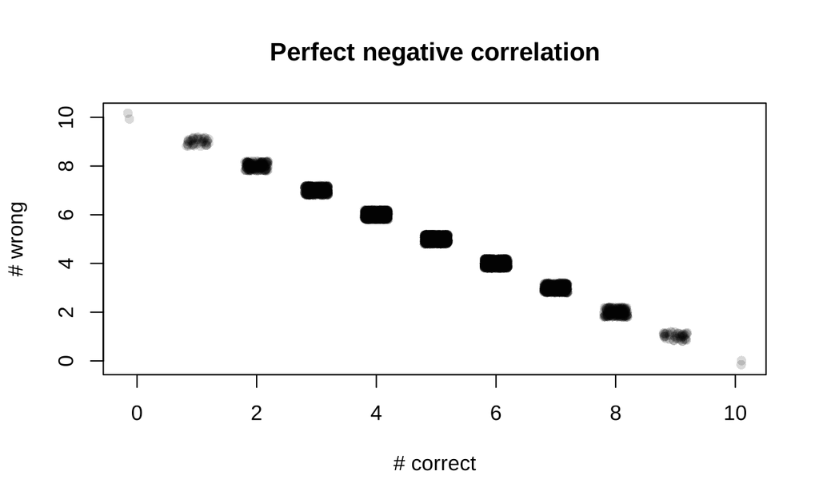

```
## cor_correct_vs_5pt_score
##                        1
```

**Interpretation.** $\mathrm{Cov}(X,10-X)=-\mathrm{Var}(X)=-2.5$ and $\rho=-1$ exactly: a perfect decreasing straight line. Multiplying the score by 5 points per question does not change the correlation (+1 with the score).

# 7 Experiment: commute time and rain (why $\mathrm{Var}(X+Y)$ needs covariance)

Your trip is a bus ride $B$ plus a walk $W$. It rains with probability 0.3 and rain slows **both**:

- $B=20+10R+\varepsilon_B$, $\varepsilon_B\sim N(0,3^2)$
- $W=10+6R+\varepsilon_W$, $\varepsilon_W\sim N(0,2^2)$

We simulate 100,000 days.

```
##    var_bus   var_walk        cov        cor
## 30.0025827 11.5171442 12.5901850  0.6772989
```

Theory says $\mathrm{Cov}(B,W)=10\cdot6\cdot\mathrm{Var}(R)=60(0.21)=12.6$. Now the variance of the total $T=B+W$, three ways: naively adding the two variances (as if the bus and walk were independent), adding the covariance term $2\,\mathrm{Cov}(B,W)$, and directly from the simulated totals:

| method | variance |
| --- | --- |
| Var(B)+Var(W) (pretend independent) | 41.51973 |
| Var(B)+Var(W)+2Cov(B,W) | 66.70010 |
| Simulated Var(B+W) | 66.70010 |

The second and third lines match; the naive first line is far too small. What does that cost you? Suppose you want to be on time 95% of the time. The “true” 95th percentile comes directly from the simulated totals. The “naive” value is what you would get by assuming independence: the mean plus 1.645 standard deviations, using the too-small variance:

```
##   true_95th_percentile naive_independent_95th
##               49.47771               45.42807
```

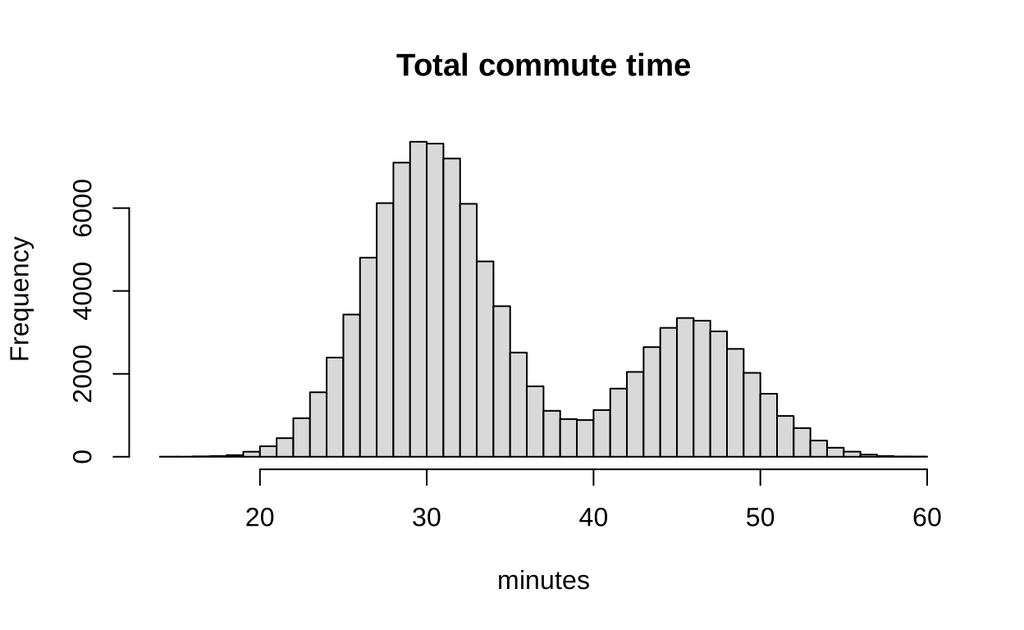

**Interpretation.** Because rain hits both parts of the trip, bad days are *bad on both ends* and the total is more spread out (a two-humped distribution: dry days and rainy days). Ignoring covariance gives a buffer that is too small. The same thing happens with money: two stocks that fall together make a riskier portfolio than their separate variances suggest, and two stocks that move oppositely *reduce* the variance of the sum.

To see the effect of the covariance alone, scramble the walk times so they no longer line up with the bus times (same marginal distributions, link broken). The variance of the total with the original pairing versus the shuffled pairing:

```
## original shuffled
## 66.70010 41.45106
```

# 8 Experiment: temperature and electricity use

A house heats when it’s cold and air-conditions when it’s hot. $X$ = outdoor temperature minus 20°C (uniform on $[-15,15]$), and energy use $Y=|X|$ plus random noise with standard deviation 1. We simulate 3,000 days; the plot title shows the correlation, and the table repeats it with the covariance.

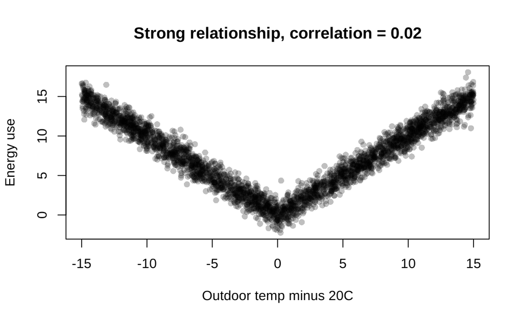

```
##        cov        cor
## 0.84262097 0.02140511
```

**Interpretation.** $Y$ is almost determined by $X$, yet the correlation is about 0: cold days (negative $x$) and hot days (positive $x$) both mean high energy use, so the positive and negative products cancel. *Always plot the data.*

# 9 A discrete joint distribution, start to finish

For a student, $X$ = number of late assignments and $Y$ = number of missed lectures, with the joint pmf below (rows are $x$, columns are $y$). The last row and column give the marginal probabilities $p_Y(y)$ and $p_X(x)$ (column and row sums), and the bottom-right corner, 1, confirms the probabilities sum to 1.

```
##        0      1      2      p_X(x)
## 0      0.2000 0.1000 0.0000 0.3000
## 1      0.1000 0.3000 0.1000 0.5000
## 2      0.0000 0.1000 0.1000 0.2000
## p_Y(y) 0.3000 0.5000 0.2000 1.0000
```

Next we compute, using the formulas from the big-picture table:

$$E[X]=\sum_x x\,p_X(x), \qquad
E[Y]=\sum_y y\,p_Y(y)$$

$$E[XY]=\sum_x\sum_y
xy\,p(x,y)$$

$$\mathrm{Cov}(X,Y)=E[XY]-E[X]\,E[Y]$$

$$\mathrm{Var}(X)=E[X^2]-\big(E[X]\big)^2,
\qquad \mathrm{Var}(Y)=E[Y^2]-\big(E[Y]\big)^2$$

$$\rho=\frac{\mathrm{Cov}(X,Y)}{\sigma_X\,\sigma_Y}$$

```
##        EX        EY       EXY       Cov      VarX      VarY      Corr
## 0.9000000 0.9000000 1.1000000 0.2900000 0.4900000 0.4900000 0.5918367
```

Check by simulating 100,000 students, where each student’s $(x,y)$ is drawn from the nine cells with the probabilities in the table:

```
##       cov       cor
## 0.2909503 0.5922088
```

**Interpretation.** $\mathrm{Cov}=1.1-0.9^2=0.29>0$ and $\rho\approx0.59$: students with more late assignments tend to miss more lectures. They are dependent: $P(0,0)=0.2$ but $p_X(0)p_Y(0)=0.09$.

# 10 Correlation is not causation

*Experiment:* daily ice-cream sales and swimming-pool injuries over a summer. Neither causes the other; **temperature** drives both. We simulate 120 summer days: temperature is Normal with mean 28°C and standard deviation 5; ice-cream sales = 50 + 8 × temperature + random noise (sd 25); injuries = 1 + 0.25 × temperature + random noise (sd 1.5). The first number below is the correlation between ice-cream sales and injuries. The second is the correlation after removing the part of each variable explained by temperature (fit a straight line of each variable on temperature and correlate what is left over).

```
##            raw_correlation after_removing_temperature
##                 0.50310804                -0.01252434
```

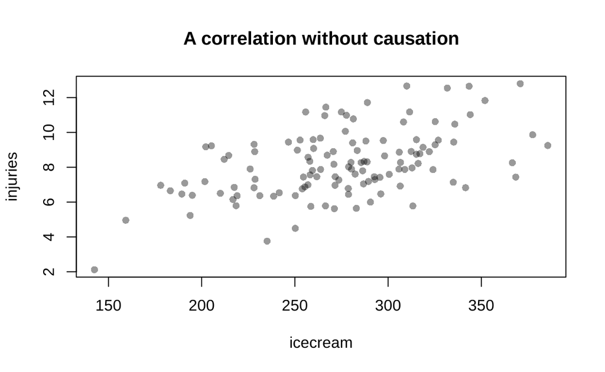

**Interpretation.** Once the effect of temperature is removed from both variables, the leftover correlation is near 0, which exposes the lurking variable. (Statisticians call this a partial correlation.)

# 11 Summary

| Experiment | Cov_sign | Lesson |
| --- | --- | --- |
| Study hours / score | + | Quadrants: average product of deviations |
| Dice: D1 and sum | + | Part of a variable is shared with the sum |
| Dice: sum and gap | 0 | Uncorrelated but dependent |
| True/false quiz | - | Perfect linear relation: rho = -1; scale-free |
| Rain commute | + | Var(X+Y) = Var X + Var Y + 2 Cov; risk and buffers |
| Temperature / energy | 0 | Correlation only sees *linear* association |